# Reproducible Research Assignment 1

Santhosh Shankar

October 17, 2015

This assignment makes use of data from a personal activity monitoring device. This device collects data at 5 minute intervals through out the day. The data consists of two months of data from an anonymous individual collected during the months of October and November, 2012 and include the number of steps taken in 5 minute intervals each day.

The dataset has been downloaded from the [Link](https://d396qusza40orc.cloudfront.net/repdata%2Fdata%2Factivity.zip) on 12-OCT-2015

The variables included in this dataset are: - steps: Number of steps taking in a 5-minute interval (missing values are coded as NA) - date: The date on which the measurement was taken in YYYY-MM-DD format - interval: Identifier for the 5-minute interval in which measurement was taken

The dataset is stored in a comma-separated-value (CSV) file and there are a total of 17,568 observations in this dataset.

# Loading and preprocessing the data

Show any code that is needed to

1. Load the data (i.e. read.csv())
2. Process/transform the data (if necessary) into a format suitable for your analysis

Read the File using function. Am using read.csv() funtion

```r
require(data.table)
require(dplyr)
## Read the File using read.csv() function
stpdata <- read.csv("activity.csv", stringsAsFactors = FALSE)
```

### Data Processing/Transforming

Transform/process the date into the form useful for our further processing * First we convert the date column from character to date format

```r
    # Format the date column into Date format %Y-%m-%d
    stpdata$date <- as.Date(stpdata$date, format = "%Y-%m-%d")
```

# What is mean total number of steps taken per day? ignore the missing values

For this part of the assignment, you can ignore the missing values in the dataset.

1. Calculate the total number of steps taken per day
2. If you do not understand the difference between a histogram and a barplot, research the difference between them. Make a histogram of the total number of steps taken each day
3. Calculate and report the mean and median of the total number of steps taken per day

First we will convert the data frame to a table for further processing. Then use group_by, summarise functions to compute values and plot the histogram.

Here is the code snippet for the same,

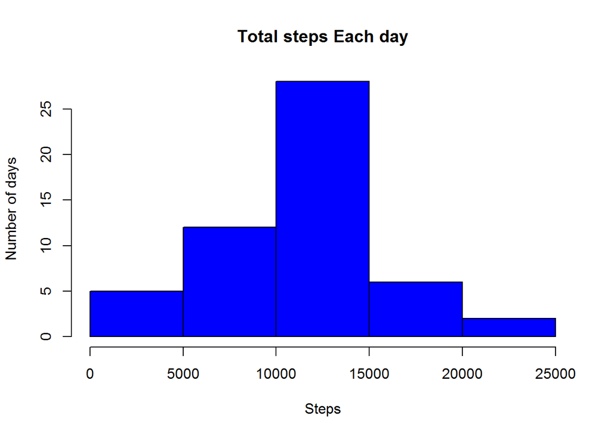

```r
    # Omit the missing values
    tempdata <- na.omit(stpdata)

    # Make table from the above data frame
    tblstpdata <- tbl_df(tempdata)

    # Group by date
    dt_stpdata <- group_by(tblstpdata, date, add = TRUE)

    # Sum up the steps for each day
    smry_data <- summarise(dt_stpdata, steps = sum(steps))

    # Plot the histogram
    hist(smry_data$steps, main = "Total steps Each day", xlab = "Steps",
         ylab = "Number of days", col = "blue")
```

```r
    # Find the median and mean values
    temp <- summary(smry_data$steps)
    mdn <- temp[3]
    mn <- temp[4]

    prntmnB <- sprintf("The Mean and Median values for the total number of steps taken per day: %d and %d", mn, mdn)
    print(prntmnB)
```

```
## [1] "The Mean and Median values for the total number of steps taken per day: 10770 and 10760"
```

# What is the average daily activity pattern?

1. Make a time series plot (i.e. type = “l”) of the 5-minute interval (x-axis) and the average number of steps taken, averaged across all days (y-axis)
2. Which 5-minute interval, on average across all the days in the dataset, contains the maximum number of steps?

Here is the code snippet for the same,

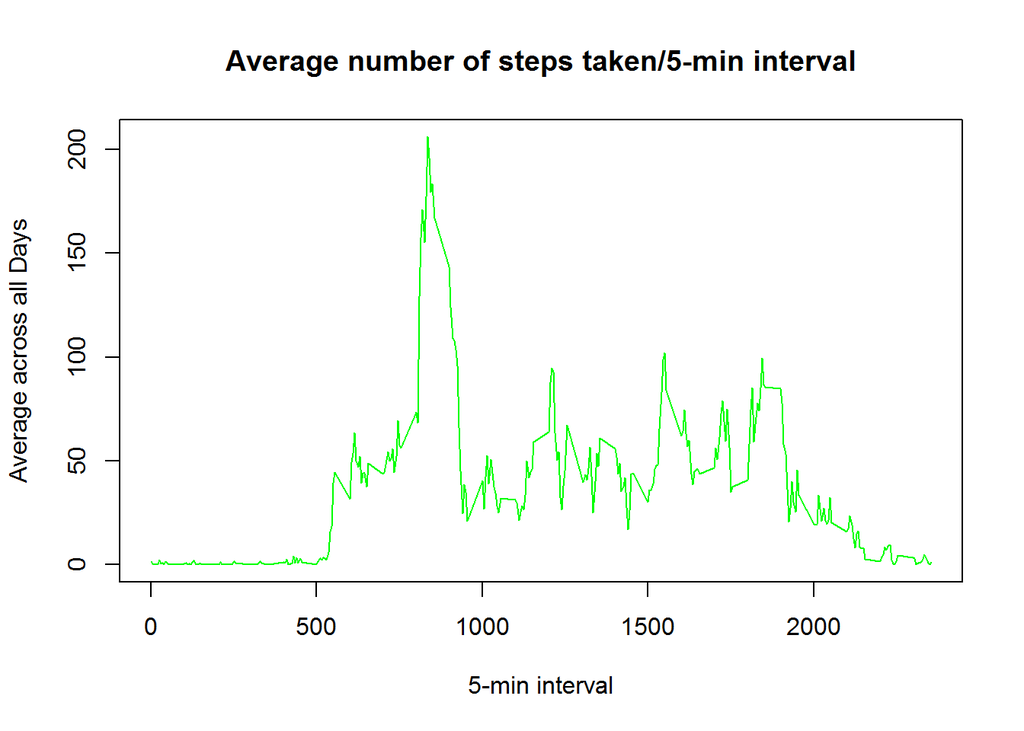

```r
    int5_stpdata <- group_by(tblstpdata, interval, add = TRUE)
    int5_avg <- summarise(int5_stpdata, steps = mean(steps))
    plot(int5_avg$interval, int5_avg$steps, type = "l", xlab = "5-min interval",
            ylab = "Average across all Days",
            main = "Average number of steps taken/5-min interval",
            col = "green")
```

```r
    ## Which 5-minute interval, on average across all the days in the dataset,
    ## contains the maximum number of steps?
    print("Time interval that has the maximum average number of steps taken per day")
```

```
## [1] "Time interval that has the maximum average number of steps taken per day"
```

```r
    int5_avg[int5_avg$steps == max(int5_avg$steps),]$interval
```

```
## [1] 835
```

# Imputing missing values

Note that there are a number of days/intervals where there are missing values (coded as NA). The presence of missing days may introduce bias into some calculations or summaries of the data.

1. Calculate and report the total number of missing values in the dataset (i.e. the total number of rows with NAs)
2. Devise a strategy for filling in all of the missing values in the dataset. The strategy does not need to be sophisticated. For example, you could use the mean/median for that day, or the mean for that 5-minute interval, etc.
3. Create a new dataset that is equal to the original dataset but with the missing data filled in.
4. Make a histogram of the total number of steps taken each day and Calculate and report the mean and median total number of steps taken per day. Do these values differ from the estimates from the first part of the assignment? What is the impact of imputing missing data on the estimates of the total daily number of steps?

Calculate and report the total number of missing values in the dataset

```r
    narows <- nrow(stpdata) - nrow(tempdata)
```

Total number of rows with missing values is 2304.

### Devise a strategy for filling in all of the missing values in the dataset.

### Strategy I am using is - Fill the missing values with avg value for that interval

```r
    # use the avg value for that interval from the data set computed in previous step
    stpdata[is.na(stpdata)] <- int5_avg[int5_avg$interval == stpdata$interval]$steps
```

Make a histogram of the total number of steps taken each day

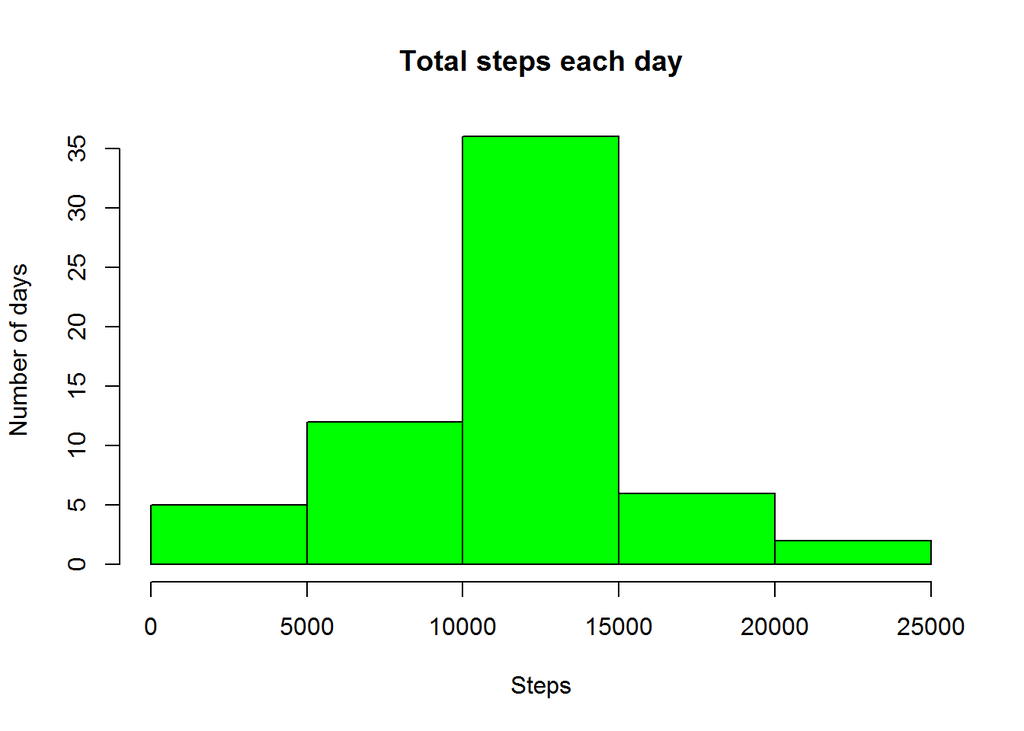

```r
    # Make table from the above data frame
    tbl_nwstp <- tbl_df(stpdata)

    # Group by date
    dt_nwstp <- group_by(tbl_nwstp, date, add = TRUE)

    # Sum up the steps
    nwsmry_data <- summarise(dt_nwstp, steps = sum(steps))


    hist(nwsmry_data$steps, main = "Total steps each day", xlab = "Steps",
         ylab = "Number of days", col = "green")
```

Calculate and report the mean and median total number of steps taken per day.

```r
    temp <- summary(nwsmry_data$steps)
    nwmdn <- temp[3]
    nwmn <- temp[4]

    prntmnA <- sprintf("After imputing the missing values, The Mean and Median values are: %d and %d", nwmn, nwmdn)
    prntmnB <- sprintf("Before imputing the missing values, The Mean and Median values are: %d and %d", mn, mdn)
```

[output not shown]

[output not shown]

# Are there differences in activity patterns between weekdays and weekends?

For this part the weekdays() function may be of some help here. Use the dataset with the filled-in missing values for this part.

1. Create a new factor variable in the dataset with two levels - “weekday” and “weekend” indicating whether a given date is a weekday or weekend day.
2. Make a panel plot containing a time series plot (i.e. type = “l”) of the 5-minute interval (x-axis) and the average number of steps taken, averaged across all weekday days or weekend days (y-axis). See the [README](https://github.com/HIRIYURS/RepData_PeerAssessment1/blob/master/README.md) file in the GitHub repository to see an example of what this plot should look like using simulated data.

Here is the code snippet for the above,

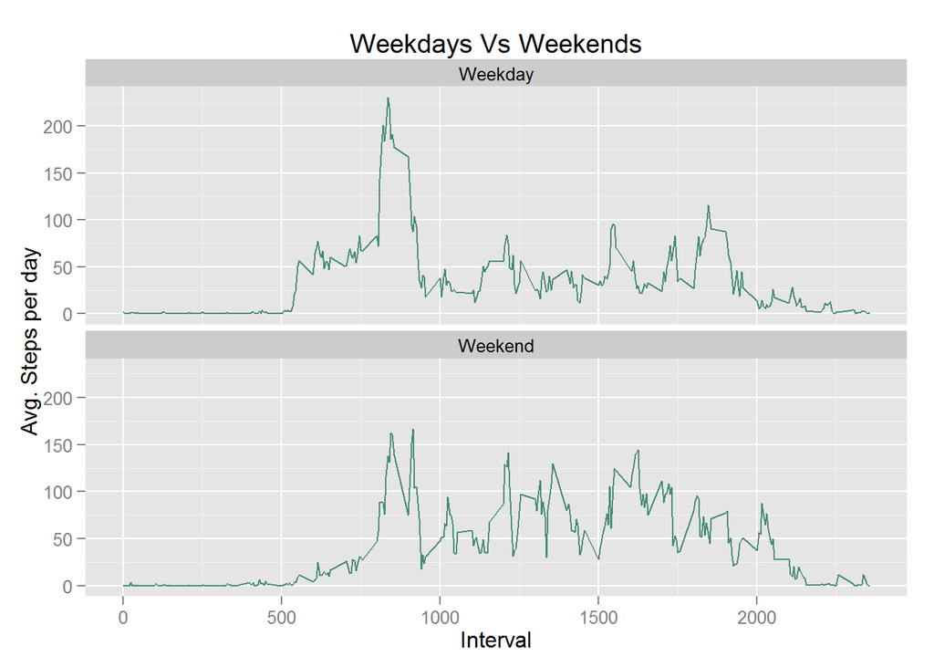

```r
    require(ggplot2)
    require(plyr)
    # Create a new factor variable in the dataset identifying weekend and weekday
    stpdata$dayofweek <- weekdays(stpdata$date, abbreviate = FALSE)
    stpdata$dayofweek <- ifelse(stpdata$dayofweek %in% c("Saturday", "Sunday"),
                                "Weekend", "Weekday")

    # Compute avewrage for weekend and weekdays
    wkdy_avg <- ddply(stpdata, .(interval, dayofweek), summarise,
                      steps = mean(steps))

    # Plot the panel plot for weekday and weekends average steps taken
    myplot <- ggplot(wkdy_avg, aes(x = interval, y = steps)) +
            geom_line(color = "aquamarine4") +
            facet_wrap(~dayofweek, nrow = 2) +
            labs(x = "Interval",
                 y = "Avg. Steps per day") +
            labs(title = "Weekdays Vs Weekends")

    print(myplot)
```

# End of the Report! Hope it was useful and easy to understand!!